# Japanese Production CDI-CAT

George

2026-01-04

# Introduction

Our goal is to develop and test via simulation a bank of CDI items and IRT parameters that can be used for a CDI-CAT in Japanese. Our approach is as follows: We first fit basic IRT models (1-parameter logistic (1PL; i.e. Rasch), 2PL, and 3PL) to CDI data and perform a model comparison. For the favored model, we then identify candidate items for removal based on low total item information, and then use the (full) item bank in a variety of computerized adaptive test (CAT) simulations on wordbank data. We provide recommendations for CAT algorithms and stopping rules to be passed on to CAT developers, and benchmark CAT performance compared to random baselines tests of a similar length.

# Data

We use the combined production data from 1160 administrations (from 912 unique participants). From this data we remove 72 children <12 months of age, who should not be producing any words yet. We also remove an additional 110 children 12+ months of age who are not yet producing any words, as these children cannot be used to fit the IRT models. Finally, we remove 39 children >38 months of age, as they are beyond the targeted age range of the CDI:WS, and the proposed CAT. The production sumscores by age for the remaining children are shown below.

| Age | N |
| --- | --- |
| 12 | 78 |
| 13 | 13 |
| 14 | 20 |
| 15 | 65 |
| 16 | 41 |
| 17 | 39 |
| 18 | 126 |
| 19 | 34 |
| 20 | 56 |
| 21 | 60 |
| 22 | 36 |
| 23 | 36 |
| 24 | 65 |
| 25 | 32 |
| 26 | 35 |
| 27 | 14 |
| 28 | 18 |
| 29 | 18 |
| 30 | 18 |
| 31 | 18 |
| 32 | 13 |
| 33 | 14 |
| 34 | 15 |
| 35 | 8 |
| 36 | 41 |
| 37 | 8 |
| 38 | 18 |

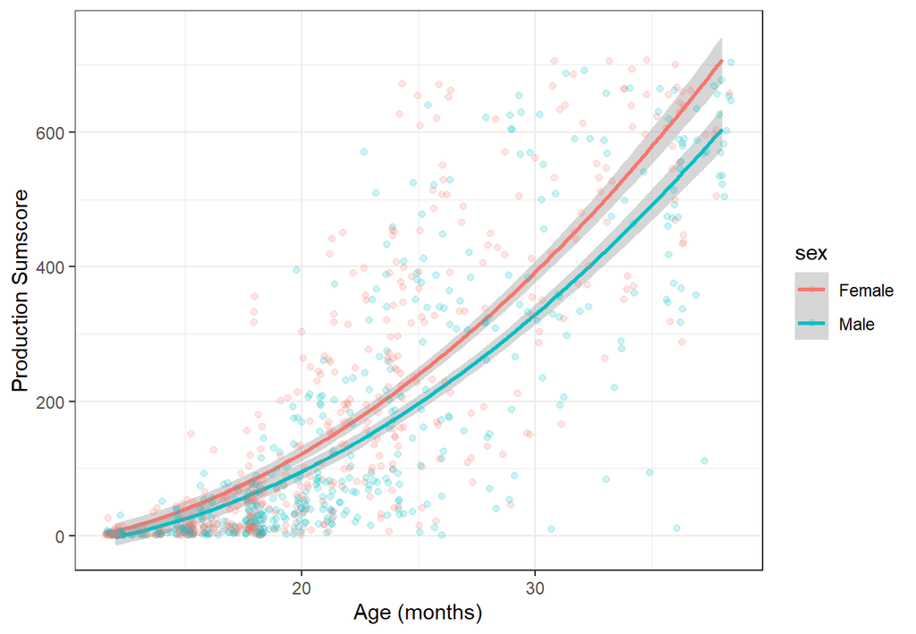

# IRT Models

We fit each type of basic IRT model (Rasch, 2PL, and 3PL) using the `mirt` package.

## Model comparison.

Compared to the Rasch model, the 2PL model fits better and is preferred by both AIC and BIC.

Comparison of Rasch and 2PL models.

| Model | AIC | BIC | logLik | df |
| --- | --- | --- | --- | --- |
| Rasch | NaN | NaN | NaN | NA |
| 2PL | NaN | NaN | NaN | 710 |

The 2PL is favored over the 3PL model by both AIC and BIC.

Comparison of 2PL and 3PL models.

| Model | AIC | BIC | logLik | df |
| --- | --- | --- | --- | --- |
| 2PL | NaN | NaN | NaN | NA |
| 3PL | NaN | NaN | NaN | 711 |

The 2PL is preferred over both the Rasch (1PL) model and the 3PL model, so we do the rest of our analyses using the 2PL model as the basis for the CAT. Next we look for linear dependencies (LD) among the items, and also check for ill-fitting items. We will remove any items that show both strong LD and poor fit.

# Item bank

## Examine Linear Dependencies

We examined each item for pairwise linear dependencies (LD) with other items using $\chi^{2}$ (Chen & Thissen, 1997), and found that 30 items show strong LD (Cramer’s $V \geq 0.5$).

## Ill-fitting items

Our next goal is to determine if all items should be included in the item bank. Items that have very bad properties should probably be dropped. We will prune any ill-fitting items ($\chi^{2}$ $p<.001$) from the full 2PL model that *also* showed strong LD.

0 items did not fit well in the full 2PL model

### Plot Item Parameters

Next, we examine the coefficients of the 2PL model. Items that are estimated to be very easy or very difficult are highlighted, as well as those at the extremes of discrimination (a1).

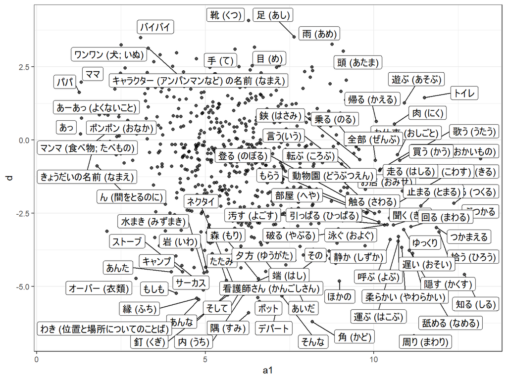

# CAT Simulations

For each wordbank subject, we simulate a CAT using a maximum of 25, 50, 100, 200, 300, or 400 items, with the termination criterion that it reach an estimated SEM of .1. For each of these simulations, we examine 1) which items were never used, 2) the median and mean number of items used, 3) the correlation of ability scores estimated from the CAT and from the full CDI, and 4) the mean standard error of the CATs.

CAT simulations with 2PL model compared to full CDI.

| Maximum Qs | Median Qs Asked | Mean Qs Asked | r with full CDI | Mean SE | Reliability | Items Never Used |
| --- | --- | --- | --- | --- | --- | --- |
| 25 | 13 | 14.850 | 0.978 | 0.146 | 0.979 | 593 |
| 50 | 13 | 23.487 | 0.984 | 0.135 | 0.982 | 548 |
| 75 | 13 | 31.015 | 0.987 | 0.130 | 0.983 | 508 |
| 100 | 13 | 38.071 | 0.988 | 0.128 | 0.984 | 474 |
| 200 | 13 | 64.065 | 0.990 | 0.125 | 0.984 | 335 |
| 300 | 13 | 88.789 | 0.990 | 0.125 | 0.984 | 229 |
| 400 | 13 | 113.271 | 0.991 | 0.125 | 0.984 | 142 |

Finally, following Makransky et al. (2016), we run a series of fixed-length CAT simulations and again compare the thetas from these CATs to the ability estimates from the full CDI. The results are quite good even for 25- and 50-item tests, but note that we add a comparison to tests of randomly-selected questions (per subject), and find that ability estimates from these tests are also strongly correlated with thetas from the full CDI. The mean standard error of the random tests shows more of a difference.

Fixed-length CAT simulations with 2PL model compared to full CDI.

| Test Length | r with full CDI | Mean SE | Reliability | Items Never Used | Random Test r with full CDI | Random Test Mean SE |
| --- | --- | --- | --- | --- | --- | --- |
| 25 | 0.982 | 0.123 | 0.985 | 489 | 0.923 | 0.246 |
| 50 | 0.990 | 0.102 | 0.990 | 339 | 0.951 | 0.197 |
| 75 | 0.994 | 0.093 | 0.991 | 259 | 0.961 | 0.178 |
| 100 | 0.995 | 0.088 | 0.992 | 180 | 0.972 | 0.160 |
| 200 | 0.998 | 0.081 | 0.994 | 24 | 0.984 | 0.125 |
| 300 | 0.999 | 0.078 | 0.994 | 0 | 0.990 | 0.110 |
| 400 | 0.999 | 0.077 | 0.994 | 0 | 0.993 | 0.097 |

### Preferred CAT Settings

Testing with a minimum of 25 items, a maximum of 50, and termination at SE = .1, and ML scoring. First we’ll do it using the MI start item, and then we’ll try choosing an age-based starting item per subject (based on mean theta for each age).

We select a starting item with a difficulty just below the average ability (theta) for each age (in months). The mean theta per age is shown below, along with the selected starting item.

| age | theta | sd | n | definition | index | item_info |
| --- | --- | --- | --- | --- | --- | --- |
| 12 | -1.79 | 0.34 | 78 | (イナイイナイ) バー | 245 | 0.56 |
| 13 | -1.68 | 0.42 | 13 | (イナイイナイ) バー | 245 | 0.64 |
| 14 | -1.50 | 0.45 | 20 | ワンワン (犬; いぬ) | 12 | 0.77 |
| 15 | -1.28 | 0.44 | 65 | ワンワン (犬; いぬ) | 12 | 1.11 |
| 16 | -1.07 | 0.50 | 41 | バイバイ | 260 | 1.55 |
| 17 | -0.95 | 0.42 | 39 | バイバイ | 260 | 1.88 |
| 18 | -0.88 | 0.48 | 126 | バイバイ | 260 | 2.06 |
| 19 | -0.72 | 0.41 | 34 | バイバイ | 260 | 2.33 |
| 20 | -0.61 | 0.45 | 56 | キャラクター (アンパンマンなど) の名前 (なまえ) | 233 | 2.54 |
| 21 | -0.42 | 0.41 | 60 | 靴 (くつ) | 99 | 5.09 |
| 22 | -0.31 | 0.28 | 36 | 靴 (くつ) | 99 | 7.75 |
| 23 | -0.23 | 0.34 | 36 | 靴 (くつ) | 99 | 9.21 |
| 24 | -0.13 | 0.37 | 65 | 足 (あし) | 115 | 9.95 |
| 25 | -0.02 | 0.48 | 32 | 足 (あし) | 115 | 13.75 |
| 26 | 0.04 | 0.55 | 35 | 雨 (あめ) | 195 | 16.41 |
| 27 | 0.01 | 0.24 | 14 | 雨 (あめ) | 195 | 14.74 |
| 28 | 0.04 | 0.34 | 18 | 雨 (あめ) | 195 | 16.78 |
| 29 | 0.18 | 0.45 | 18 | 頭 (あたま) | 116 | 20.64 |
| 30 | 0.19 | 0.25 | 18 | 頭 (あたま) | 116 | 20.43 |
| 31 | 0.28 | 0.60 | 18 | トイレ | 151 | 25.29 |
| 32 | 0.44 | 0.35 | 13 | トイレ | 151 | 28.87 |
| 33 | 0.42 | 0.46 | 14 | トイレ | 151 | 30.95 |
| 34 | 0.45 | 0.37 | 15 | お買い物 (おかいもの) | 584 | 29.61 |
| 35 | 0.68 | 0.56 | 8 | 作る (つくる) | 613 | 38.17 |
| 36 | 0.43 | 0.38 | 41 | トイレ | 151 | 30.47 |
| 37 | 0.47 | 0.38 | 8 | お買い物 (おかいもの) | 584 | 33.11 |
| 38 | 0.70 | 0.26 | 18 | 作る (つくる) | 613 | 37.66 |

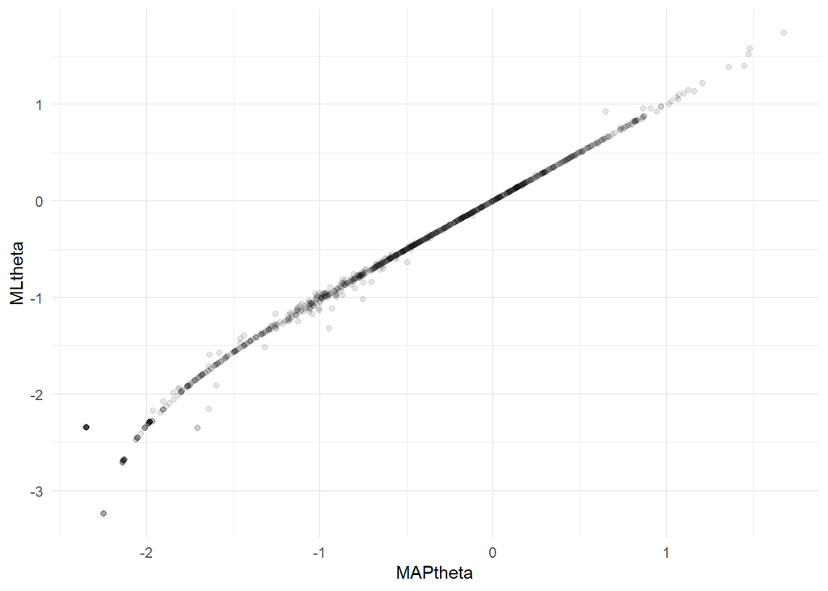

CAT simulations with min=25, max=50, stopping at SE=0.1.

| Scoring / Start Item | Median Qs Asked | Mean Qs Asked | r with full CDI | Mean SE | Reliability | Items Never Used |
| --- | --- | --- | --- | --- | --- | --- |
| ML / MI | 25 | 31.302 | 0.984 | 0.134 | 0.982 | 447 |
| MAP / MI | 25 | 30.931 | 0.987 | 0.114 | 0.987 | 449 |
| ML / age-based | 25 | 31.259 | 0.984 | 0.134 | 0.982 | 443 |
| MAP / age-based | 25 | 30.931 | 0.988 | 0.114 | 0.987 | 447 |

## Age analysis

Correlation between fixed-length CAT ability estimates and the full CDI.

| Test Length | [11,14) mos | [14,17) mos | [17,20) mos | [20,23) mos | [23,26) mos | [26,29) mos | [29,32) mos | [32,35) mos | [35,38] mos |
| --- | --- | --- | --- | --- | --- | --- | --- | --- | --- |
| 25 | 0.793 | 0.918 | 0.965 | 0.963 | 0.964 | 0.988 | 0.979 | 0.814 | 0.969 |
| 50 | 0.860 | 0.954 | 0.980 | 0.971 | 0.981 | 0.991 | 0.989 | 0.920 | 0.978 |
| 75 | 0.912 | 0.976 | 0.984 | 0.985 | 0.989 | 0.994 | 0.993 | 0.932 | 0.982 |
| 100 | 0.924 | 0.984 | 0.989 | 0.989 | 0.992 | 0.995 | 0.995 | 0.948 | 0.984 |
| 200 | 0.990 | 0.990 | 0.998 | 0.996 | 0.996 | 0.998 | 0.998 | 0.972 | 0.991 |
| 300 | 0.995 | 0.991 | 0.999 | 0.997 | 0.999 | 0.999 | 0.999 | 0.989 | 0.996 |
| 400 | 0.996 | 0.991 | 0.999 | 0.999 | 1.000 | 1.000 | 1.000 | 0.996 | 0.999 |

Correlation between the preferred CAT’s ability estimates and the full CDI.

| Scoring / Start Item | [11,14) mos | [14,17) mos | [17,20) mos | [20,23) mos | [23,26) mos | [26,29) mos | [29,32) mos | [32,35) mos | [35,38] mos |
| --- | --- | --- | --- | --- | --- | --- | --- | --- | --- |
| ML / MI | 0.905 | 0.94 | 0.97 | 0.95 | 0.972 | 0.99 | 0.978 | 0.898 | 0.971 |
| MAP / MI | 0.858 | 0.951 | 0.972 | 0.965 | 0.967 | 0.987 | 0.979 | 0.893 | 0.971 |
| ML / age-based | 0.912 | 0.945 | 0.967 | 0.951 | 0.97 | 0.989 | 0.976 | 0.898 | 0.972 |
| MAP / age-based | 0.875 | 0.954 | 0.973 | 0.966 | 0.966 | 0.987 | 0.976 | 0.891 | 0.972 |

Below we show the distribution of ability (theta) from the 2PL model by age.

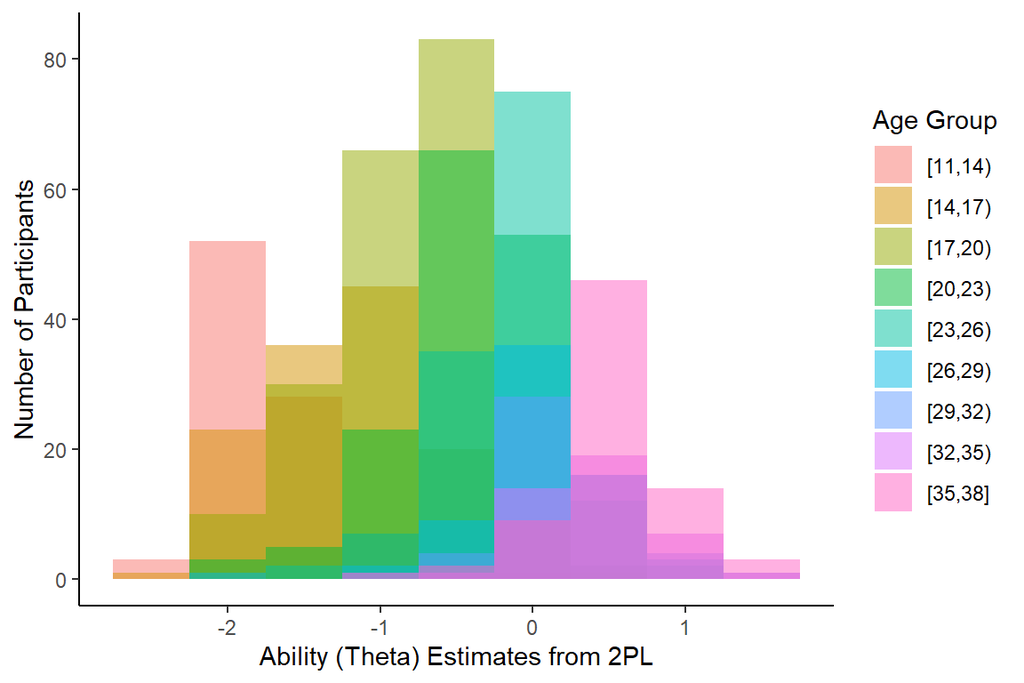

## Ability analysis

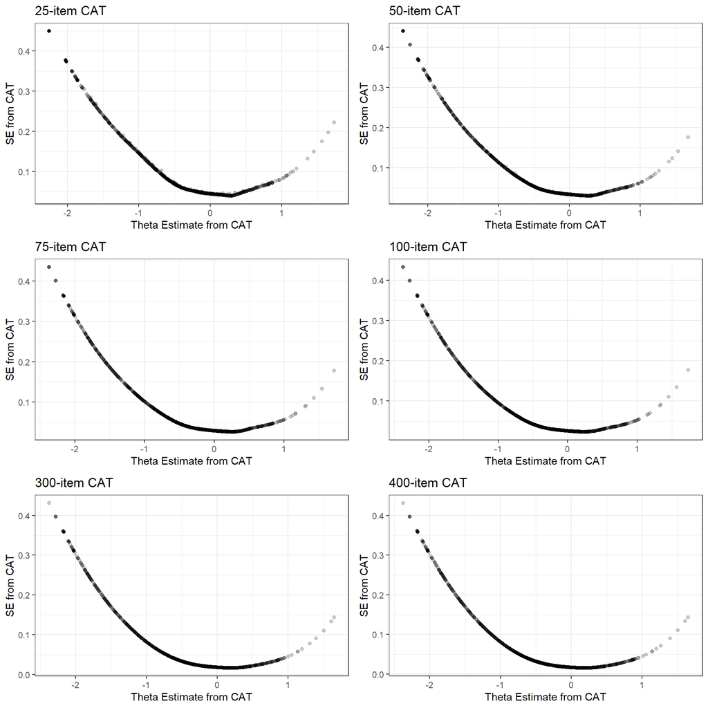

## Item selection for item bank

Of the 711 pruned CDI:WS items, 372 were selected on one or more administrations of the fixed-length 50-item CATs simulated from the wordbank data. Which items were most frequently selected for the fixed-length 50-item CAT? Shown in the table below, only 4 items were selected on more at least 50% of the tests.

Items chosen on at least 50% of the 50-item CATs.

| Item | Proportion |
| --- | --- |
| item_382 | 1.00 |
| item_214 | 0.75 |
| item_185 | 0.64 |
| item_159 | 0.56 |

Below we show the overall distribution of how many of the 711 pruned CDI:WS items were selected on what percent of the CATs of varying length (50, 75, or 100 items). Note that we do not include in the graph the number of items that were never selected on each test: 339 items never selected on the 50-item test, 259 items on the 75-item test, and 180 items never selected on the 100-item test. The longer the test, the less skewed the distribution, but even on the 100-item CAT most of the appearing items are selected less than a third of the time.

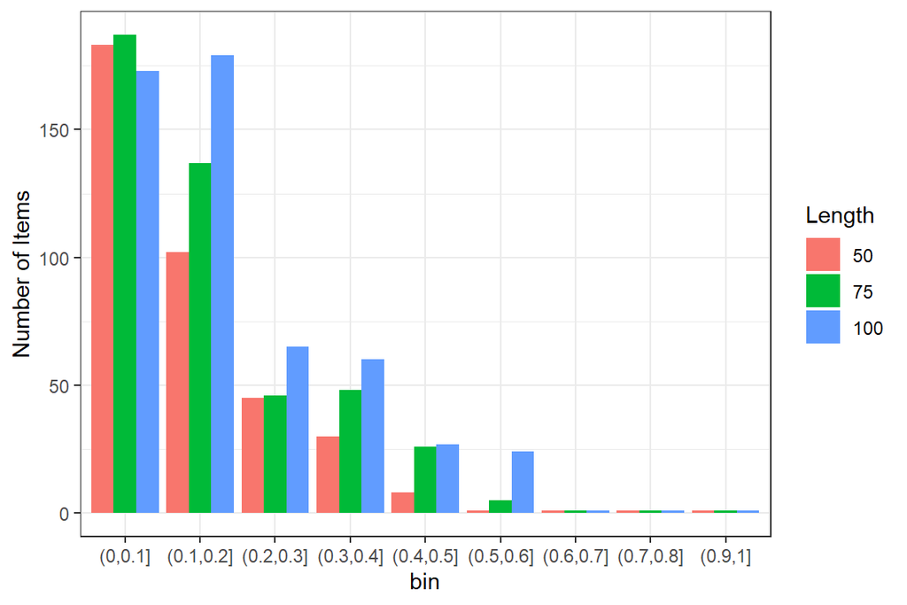

Below we show the 229 items from the pruned CDI:WS that were never selected on the maximum 300-item CAT.

| item_54 | item_323 | item_602 | item_437 |
| --- | --- | --- | --- |
| item_71 | item_356 | item_613 | item_439 |
| item_72 | item_403 | item_616 | item_442 |
| item_77 | item_405 | item_618 | item_443 |
| item_78 | item_407 | item_632 | item_451 |
| item_83 | item_412 | item_635 | item_452 |
| item_101 | item_414 | item_648 | item_456 |
| item_121 | item_415 | item_650 | item_457 |
| item_124 | item_416 | item_706 | item_459 |
| item_172 | item_422 | item_707 | item_462 |
| item_173 | item_425 | item_708 | item_463 |
| item_176 | item_426 | item_26 | item_465 |
| item_180 | item_429 | item_36 | item_469 |
| item_193 | item_435 | item_47 | item_470 |
| item_199 | item_440 | item_75 | item_472 |
| item_201 | item_441 | item_76 | item_474 |
| item_210 | item_444 | item_81 | item_479 |
| item_216 | item_447 | item_84 | item_480 |
| item_217 | item_448 | item_95 | item_481 |
| item_221 | item_449 | item_111 | item_484 |
| item_229 | item_453 | item_119 | item_485 |
| item_230 | item_464 | item_123 | item_488 |
| item_231 | item_466 | item_125 | item_489 |
| item_232 | item_467 | item_128 | item_492 |
| item_233 | item_471 | item_137 | item_495 |
| item_240 | item_476 | item_141 | item_496 |
| item_241 | item_477 | item_143 | item_499 |
| item_242 | item_478 | item_152 | item_500 |
| item_245 | item_483 | item_190 | item_502 |
| item_246 | item_487 | item_194 | item_518 |
| item_247 | item_490 | item_197 | item_519 |
| item_252 | item_491 | item_198 | item_531 |
| item_253 | item_493 | item_200 | item_534 |
| item_257 | item_494 | item_262 | item_546 |
| item_259 | item_497 | item_275 | item_547 |
| item_260 | item_498 | item_287 | item_553 |
| item_261 | item_501 | item_295 | item_554 |
| item_264 | item_503 | item_299 | item_559 |
| item_266 | item_504 | item_301 | item_562 |
| item_267 | item_506 | item_305 | item_565 |
| item_272 | item_507 | item_321 | item_569 |
| item_273 | item_509 | item_322 | item_573 |
| item_276 | item_510 | item_324 | item_574 |
| item_277 | item_513 | item_349 | item_575 |
| item_278 | item_515 | item_381 | item_576 |
| item_279 | item_527 | item_388 | item_577 |
| item_280 | item_539 | item_408 | item_588 |
| item_284 | item_545 | item_417 | item_620 |
| item_290 | item_549 | item_419 | item_621 |
| item_300 | item_551 | item_421 | item_624 |
| item_331 | item_557 | item_423 | item_638 |
| item_336 | item_558 | item_424 | item_642 |
| item_307 | item_560 | item_428 | item_643 |
| item_308 | item_561 | item_431 | item_644 |
| item_309 | item_566 | item_432 | item_645 |
| item_340 | item_567 | item_433 | item_54 |
| item_315 | item_568 | item_434 | item_71 |
| item_316 | item_572 | item_436 | item_72 |

What about the items that are most selected across all of the CATs (25-400-item)? Here are the top 50:

| item_382 | item_364 | item_679 | item_9 | item_669 |
| --- | --- | --- | --- | --- |
| item_214 | item_134 | item_35 | item_389 | item_680 |
| item_185 | item_524 | item_57 | item_2 | item_313 |
| item_159 | item_65 | item_8 | item_86 | item_42 |
| item_135 | item_397 | item_580 | item_37 | item_294 |
| item_673 | item_102 | item_3 | item_377 | item_113 |
| item_202 | item_399 | item_12 | item_376 | item_701 |
| item_703 | item_661 | item_520 | item_705 | item_62 |
| item_209 | item_398 | item_208 | item_393 | item_665 |
| item_97 | item_528 | item_15 | item_379 | item_396 |

## Example CAT

We now show an example CAT for two simulated participants, one with ability (theta) = 0, and one with theta = 1. The CAT gives a minimum of 25 questions and terminates either when SEM=0.1 or when 50 items is reached. The theta estimates over the test for each participant is shown below, with selected item indices on the x axis. The theta=0 participant (left) answered 25 questions, and the theta=1 participant (right) answered 26. The final estimated theta for the theta=0 participant was 0.063, and for the theta=1 participant was 1.124. The package `mirtCAT` can be directly used to simply generate a web interface (Shiny app) that allows such CATs to be run on real participants, as well as the simulations we have conducted here.

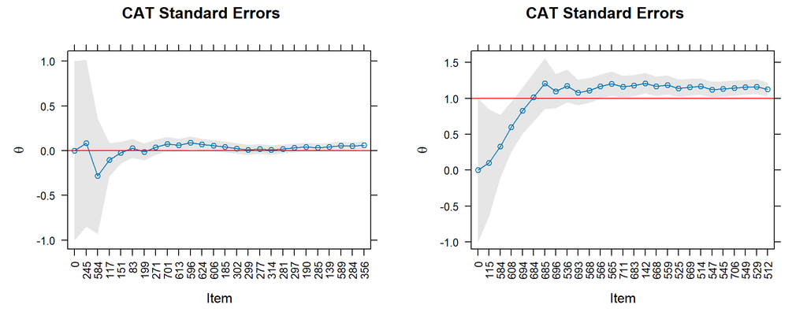

### References

Makransky, G., Dale, P. S., Havmose, P. and Bleses, D. (2016). An Item Response Theory–Based, Computerized Adaptive Testing Version of the MacArthur–Bates Communicative Development Inventory: Words & Sentences (CDI:WS). *Journal of Speech, Language, and Hearing Research*. 59(2), pp. 281-289.